# Problema 1 - Checkpoint 4

Marcos Antonio Silva Nascimento (marcos.nascimento@ccc.ufcg.edu.br)

26 de maio de 2017

```r
library("dplyr")
library("tidyr")
library("ggplot2")
library("readr")
dados = read_csv(file = "../dados/series_from_imdb.csv")
dados = dados %>% filter(series_name %in% c("13 Reasons Why", "Sense8", "Black Mirror"))
```

# `Sense8`

**Descricao da variavel classificacao do usuario (UserRating)**

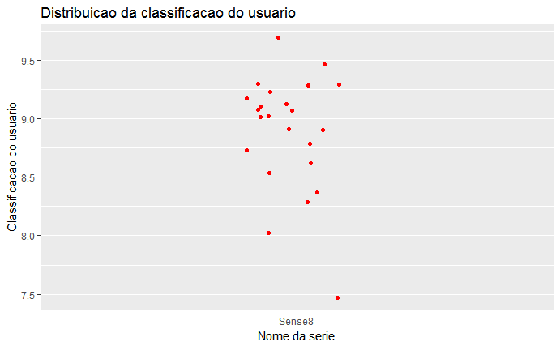

```r
dados %>%
  filter(series_name == "Sense8") %>%
    ggplot(aes(x = series_name, y = UserRating)) +
    geom_jitter(width = .1, color = "red") +
  labs(title = "Distribuicao da classificacao do usuario", x="Nome da serie", y="Classificacao do usuario")
```

Podemos perceber que segundo a distribuicao da classificacao de usuarios no grafico acima, Sense8 tem apenas um valor estranho(~7.5). Existe variacao e entre os valores frequentes tem-se a classificacao 9. Isto fica claro se observarmos o histograma logo abaixo com a contagem de frequencia das classificacoes.

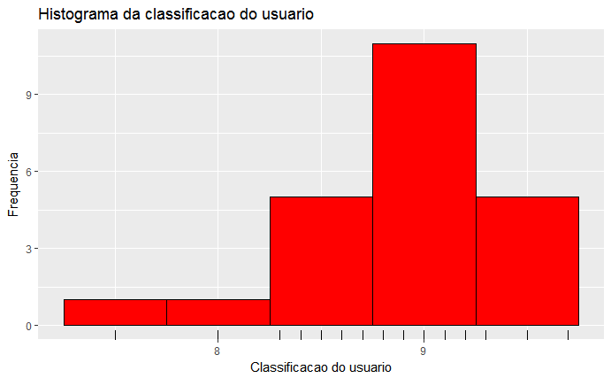

```r
dados %>%
  filter(series_name == "Sense8") %>%
    ggplot(aes(x = UserRating)) +
    geom_histogram(binwidth = .5, fill = "red", color = "black") +
    geom_rug() +
  labs(title = "Histograma da classificacao do usuario", x="Classificacao do usuario", y = "Frequencia")
```

Como a frequencia da classificacao 9 e maior entao espera-se que a mediana(9) e a media(8.891304) estejam neste entorno.

```r
median((dados %>%  filter(series_name == "Sense8"))$UserRating)
```

```
[1] 9
```

```r
mean((dados %>%  filter(series_name == "Sense8"))$UserRating)
```

```
[1] 8.891304
```

Podemos tambem observar, no grafico abaixo, a distribuicao de classificacao por temporada. A segunda temporada e melhor classificada se comparada a primeira temporada, em termos de mediana, e a variacao da classificacao da primeira foi maior do que na segunda.

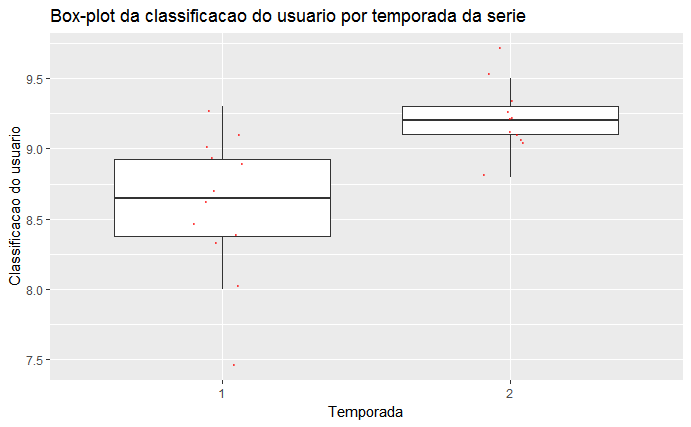

```r
dados %>%  filter(series_name == "Sense8") %>%
    ggplot(aes(x = as.character(season), y = UserRating)) +
    geom_boxplot(outlier.color = NA) +
    geom_jitter(width = .1, size = .5, alpha = .5, color = "red")+
  labs(title = "Box-plot da classificacao do usuario por temporada da serie", x="Temporada", y="Classificacao do usuario")
```

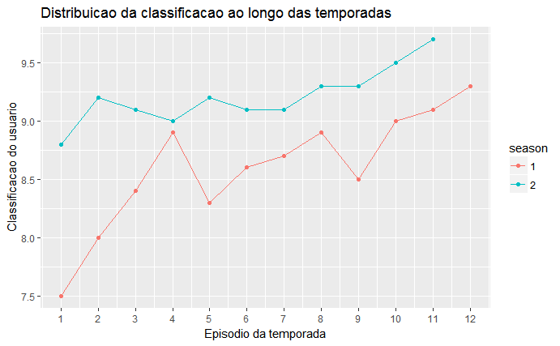

```r
dados %>%  filter(series_name == "Sense8") %>%
  mutate(season = as.character(season)) %>%
  ggplot(aes(x = season_ep, y = UserRating, color = season)) +
  geom_line() +
  geom_point()+
  scale_x_continuous(breaks=seq(1, 12, 1)) +
  labs(title = "Distribuicao da classificacao ao longo das temporadas", x="Episodio da temporada", y="Classificacao do usuario")
```

Podemos ainda verificar a existencia de uma correlacao entre o episodio da temporada e sua classificacao e podemos perceber que a mesma existe. Existe uma correlacao linear, aparentemente forte, entre essas duas variaveis, ou seja, o episodio da temporada influencia diretamente na classificacao do episodio e virse e versa.

```r
dados %>%  filter(series_name == "Sense8") %>%
    group_by(season) %>%
    summarise(correlacao_linear = cor(season_ep, UserRating,
                                      method = "pearson"),
              correlacao_kendall = cor(season_ep, UserRating,
                                       method = "kendall"))
```

| season | correlacao_linear | correlacao_kendall |
| --- | --- | --- |
| 1 | 0.8445778 | 0.7481134 |
| 2 | 0.8447368 | 0.6864931 |

**Descricao da variavel votos dos usuarios (UserVotes)**

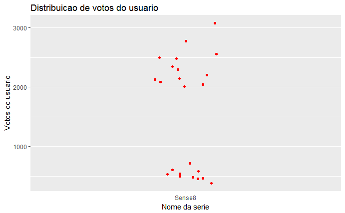

```r
dados %>%
  filter(series_name == "Sense8") %>%
    ggplot(aes(x = series_name, y = UserVotes)) +
    geom_jitter(width = .1, color = "red") +
  labs(title = "Distribuicao de votos do usuario", x="Nome da serie", y="Votos do usuario")
```

Podemos perceber que segundo a distribuicao de votos dos usuarios para cada episodio da serie no grafico acima, Sense8 tem dois grupos de valores distintos(votos < 1000 e votos >= 2000). Quanto a mediana temos 2047 e a media 1562.043. O valor indicado para media e pouco represetativo da distribuicao de votos por causa dos grupos de valores dispersos.

```r
median((dados %>%  filter(series_name == "Sense8"))$UserVotes)
```

```
[1] 2047
```

```r
mean((dados %>%  filter(series_name == "Sense8"))$UserVotes)
```

```
[1] 1562.043
```

Podemos tambem observar no grafico abaixo, a distribuicao de votos por temporada. A primeira temporada e melhor votada se comparada a segunda temporada, em termos de mediana, e a variacao de votos da primeira foi maior do que na segunda.

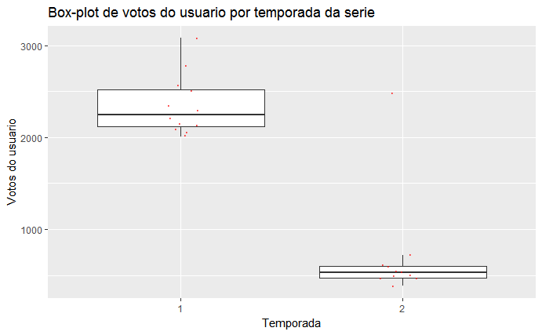

```r
dados %>%  filter(series_name == "Sense8") %>%
    ggplot(aes(x = as.character(season), y = UserVotes)) +
    geom_boxplot(outlier.color = NA) +
    geom_jitter(width = .1, size = .5, alpha = .5, color = "red")+
  labs(title = "Box-plot de votos do usuario por temporada da serie", x="Temporada", y="Votos do usuario")
```

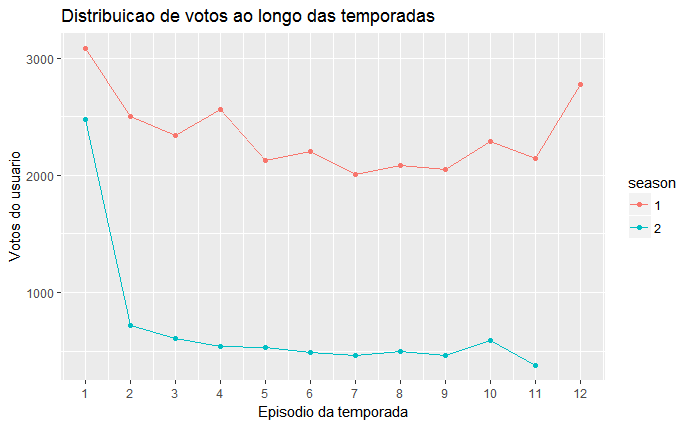

```r
dados %>%  filter(series_name == "Sense8") %>%
  mutate(season = as.character(season)) %>%
  ggplot(aes(x = season_ep, y = UserVotes, color = season)) +
  geom_line() +
  geom_point()+
  scale_x_continuous(breaks=seq(1, 12, 1)) +
  labs(title = "Distribuicao de votos ao longo das temporadas", x="Episodio da temporada", y="Votos do usuario")
```

```r
dados %>%  filter(series_name == "Sense8") %>%
    group_by(season) %>%
    summarise(correlacao_linear = cor(season_ep, UserVotes,
                                      method = "pearson"),
              correlacao_kendall = cor(season_ep, UserVotes,
                                       method = "kendall"))
```

| season | correlacao_linear | correlacao_kendall |
| --- | --- | --- |
| 1 | -0.3781660 | -0.2727273 |
| 2 | -0.5887624 | -0.7090909 |

# `Black Mirror`

**Descricao da variavel classificacao do usuario (UserRating)**

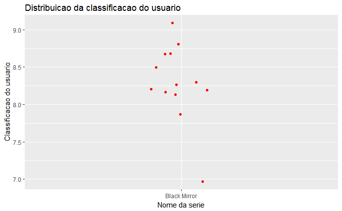

```r
dados %>%
  filter(series_name == "Black Mirror") %>%
    ggplot(aes(x = series_name, y = UserRating)) +
    geom_jitter(width = .1, color = "red") +
  labs(title = "Distribuicao da classificacao do usuario", x="Nome da serie", y="Classificacao do usuario")
```

Podemos perceber que segundo a classificacao de usuarios IMDB acima, Black Mirror tem apenas um valor estranho(~7.0). Existe variacao e dentre os valores frequentes temos as classificacoes de 8.0 e 8.5. Isto fica claro se observar-mos o histograma abaixo.

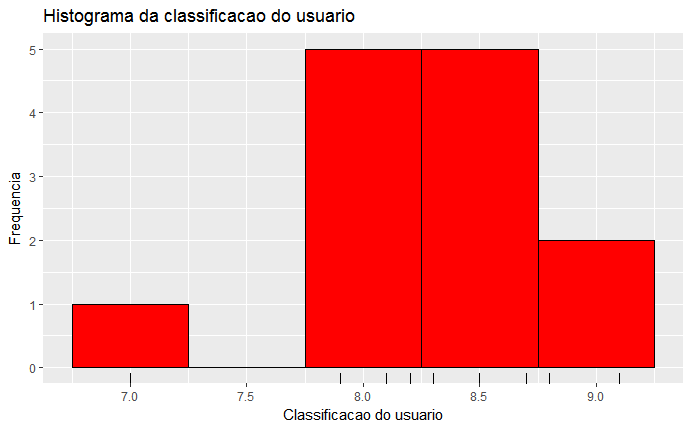

```r
dados %>%
  filter(series_name == "Black Mirror") %>%
    ggplot(aes(x = UserRating)) +
    geom_histogram(binwidth = .5, fill = "red", color = "black") +
    geom_rug() +
  labs(title = "Histograma da classificacao do usuario", x="Classificacao do usuario", y = "Frequencia")
```

Como a frequencia da classificacao concentra-se em 8.0 e 8.5 entao espera-se que a mediana esteja neste entorno. Neste caso, houve a coincidencia da mediana e da media(8.3).

```r
median((dados %>%  filter(series_name == "Black Mirror"))$UserRating)
```

```
[1] 8.3
```

```r
mean((dados %>%  filter(series_name == "Black Mirror"))$UserRating)
```

```
[1] 8.307692
```

Podemos tambem observar a distribuicao de classificacao por temporada de Black Mirror. A terceira temporada e melhor classificada se comparada a primeira e a segunda temporada, em termos de mediana, e a variacao da classificacao da segunda temporada foi maior do que na primeira e terceira. Pode-se observar tambem que a temporada com menor classificacao dentre as tres foi a segunda temporada como podemos ver abaixo.

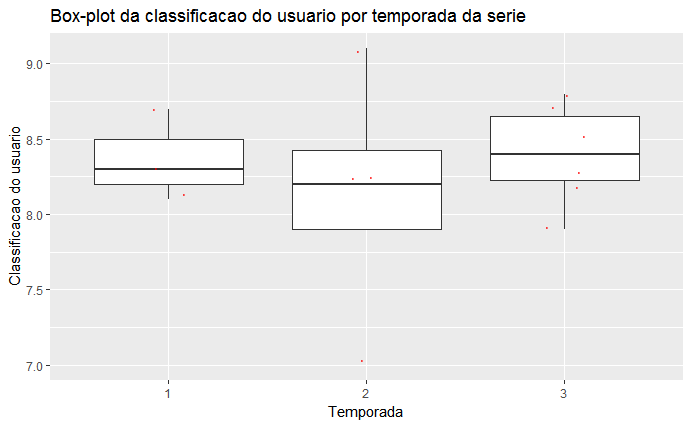

```r
dados %>%  filter(series_name == "Black Mirror") %>%
    ggplot(aes(x = as.character(season), y = UserRating)) +
    geom_boxplot(outlier.color = NA) +
    geom_jitter(width = .1, size = .5, alpha = .5, color = "red")+
  labs(title = "Box-plot da classificacao do usuario por temporada da serie", x="Temporada", y="Classificacao do usuario")
```

Com o passar dos episodios de Black Mirror a unica temporada que a classificacao so subiu foi a primeira, enquanto que na segunda e terceira temporada vemos uma variacao da classificacao. Dentre as variacoes a temporada que mais teve queda na classificacao sendo a segunda temporada (o episodio 3 chegou a ter a classificacao mais baixa da serie) como podemos ver abaixo.

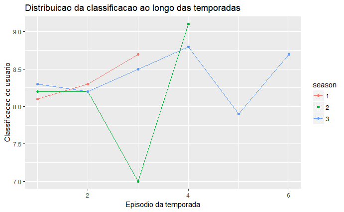

```r
dados %>%  filter(series_name == "Black Mirror") %>%
  mutate(season = as.character(season)) %>%
  ggplot(aes(x = season_ep, y = UserRating, color = season)) +
  geom_line() +
  geom_point() +
labs(title = "Distribuicao da classificacao ao longo das temporadas", x="Episodio da temporada", y="Classificacao do usuario")
```

Quanto a correlacao entre o episodio da temporada e sua classificacao podemos perceber a existencia de uma correlacao linear, aparentemente forte, entre essas duas variaveis apenas na primeira temporada.

```r
dados %>%  filter(series_name == "Black Mirror") %>%
    group_by(season) %>%
    summarise(correlacao_linear = cor(season_ep, UserRating,
                                      method = "pearson"),
              correlacao_kendall = cor(season_ep, UserRating,
                                       method = "kendall"))
```

| season | correlacao_linear | correlacao_kendall |
| --- | --- | --- |
| 1 | 0.9819805 | 1.0000000 |
| 2 | 0.2247333 | 0.1825742 |
| 3 | 0.2236068 | 0.2000000 |

**Descricao da variavel votos dos usuarios (UserVotes)**

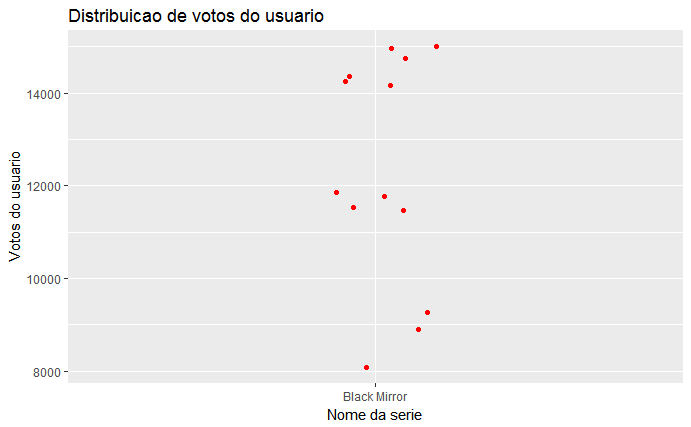

```r
dados %>%
  filter(series_name == "Black Mirror") %>%
    ggplot(aes(x = series_name, y = UserVotes)) +
    geom_jitter(width = .1, color = "red") +
  labs(title = "Distribuicao de votos do usuario", x="Nome da serie", y="Votos do usuario")
```

Podemos perceber que segundo a distribuicao de votos dos usuarios do IMDB acima, Black Mirror tem votos dispersos. Em termos de media temos 12336.62 e de mediana 11844.

```r
median((dados %>%  filter(series_name == "Black Mirror"))$UserVotes)
```

```
[1] 11844
```

```r
mean((dados %>%  filter(series_name == "Black Mirror"))$UserVotes)
```

```
[1] 12336.62
```

Podemos tambem observar a distribuicao de votos por temporada de Black Mirror. A primeira temporada e melhor votada se comparada a segunda e a terceira temporada, em termos de mediana, e a variacao da votos da terceira temporada foi maior do que na primeira e segunda. Pode-se observar tambem que ocorre um empate entre a mediana de votos da segunda e da terceira temporada como podemos ver abaixo.

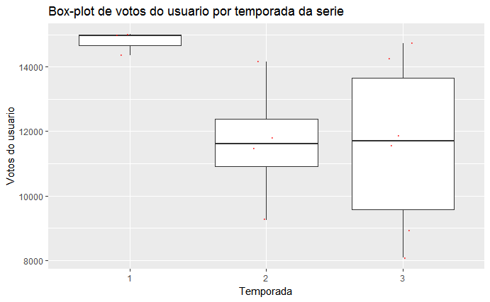

```r
dados %>%  filter(series_name == "Black Mirror") %>%
    ggplot(aes(x = as.character(season), y = UserVotes)) +
    geom_boxplot(outlier.color = NA) +
    geom_jitter(width = .1, size = .5, alpha = .5, color = "red")+
  labs(title = "Box-plot de votos do usuario por temporada da serie", x="Temporada", y="Votos do usuario")
```

Com o passar dos episodios de Black Mirror a unica temporada que manteve o numero de votos foi a primeira(episodios 1 a 2), enquanto que na segunda e terceira temporada vemos uma variacao do numero de votos. Dentre as variacoes a temporada que mais teve queda no numero de votos sendo a terceira temporada (o episodio 5 chegou a ter o menor numero de votos da serie) como podemos ver abaixo.

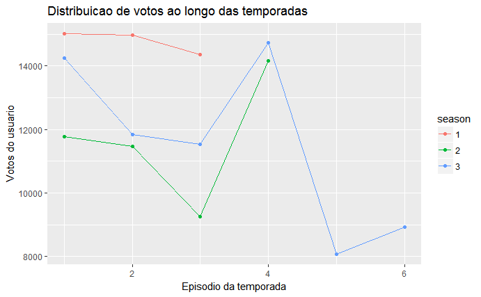

```r
dados %>%  filter(series_name == "Black Mirror") %>%
  mutate(season = as.character(season)) %>%
  ggplot(aes(x = season_ep, y = UserVotes, color = season)) +
  geom_line() +
  geom_point() +
  labs(title = "Distribuicao de votos ao longo das temporadas", x="Episodio da temporada", y="Votos do usuario")
```

Quanto a correlacao entre o episodio da temporada e seu numero de votos podemos perceber a existencia de uma correlacao linear negativa, aparentemente forte, entre essas duas variaveis apenas na primeira temporada.

```r
dados %>%  filter(series_name == "Black Mirror") %>%
    group_by(season) %>%
    summarise(correlacao_linear = cor(season_ep, UserVotes,
                                      method = "pearson"),
              correlacao_kendall = cor(season_ep, UserVotes,
                                       method = "kendall"))
```

| season | correlacao_linear | correlacao_kendall |
| --- | --- | --- |
| 1 | -0.8845023 | -1.0000000 |
| 2 | 0.3171782 | 0.0000000 |
| 3 | -0.6885087 | -0.4666667 |

# `13 Reasons Why`

**Descricao da variavel classificacao do usuario (UserRating)**

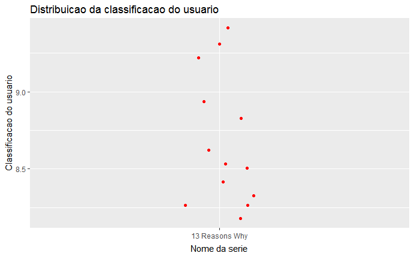

```r
dados %>%
  filter(series_name == "13 Reasons Why") %>%
    ggplot(aes(x = series_name, y = UserRating)) +
    geom_jitter(width = .1, color = "red") +
  labs(title = "Distribuicao da classificacao do usuario", x="Nome da serie", y="Classificacao do usuario")
```

Podemos perceber que segundo a classificacao de usuarios IMDB acima, 13 Reasons Why nao possui valores estranhos. Existe pouca variacao se comparado as series Sense8 e Black Mirror e dentre os valores frequentes temos as classificacoes de 8.5. Isto fica ainda mais claro no histograma abaixo.

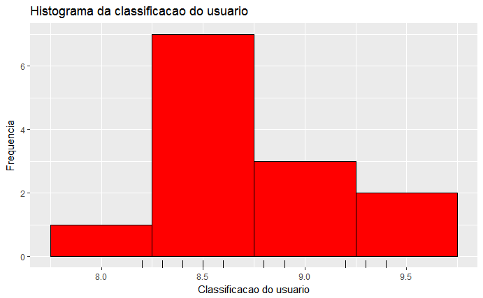

```r
dados %>%
  filter(series_name == "13 Reasons Why") %>%
    ggplot(aes(x = UserRating)) +
    geom_histogram(binwidth = .5, fill = "red", color = "black") +
    geom_rug() +
  labs(title = "Histograma da classificacao do usuario", x="Classificacao do usuario", y = "Frequencia")
```

Como a frequencia da classificacao concentra-se em 8.5 entao espera-se que a mediana esteja neste entorno. Neste caso, quase houve a coincidencia da mediana(8.5) e da media(8.669231).

```r
median((dados %>%  filter(series_name == "13 Reasons Why"))$UserRating)
```

```
[1] 8.5
```

```r
mean((dados %>%  filter(series_name == "13 Reasons Why"))$UserRating)
```

```
[1] 8.669231
```

Podemos tambem observar a distribuicao de classificacao por temporada de 13 Reasons Why. A primeira temporada, unica presente nos dados, tem classificacao em termos de mediana de 8.5 como vemos no grafico abaixo.

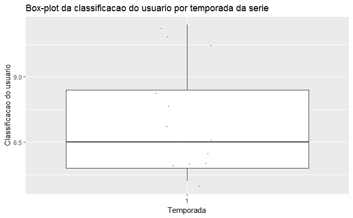

```r
dados %>%  filter(series_name == "13 Reasons Why") %>%
    ggplot(aes(x = as.character(season), y = UserRating)) +
    geom_boxplot(outlier.color = NA) +
    geom_jitter(width = .1, size = .5, alpha = .5, color = "red")+
  labs(title = "Box-plot da classificacao do usuario por temporada da serie", x="Temporada", y="Classificacao do usuario")
```

Com o passar dos episodios de 13 Reasons Why da primeira temporada a classificacao mais baixa foi registrada antes do episodio 5 como podemos ver no grafico abaixo.

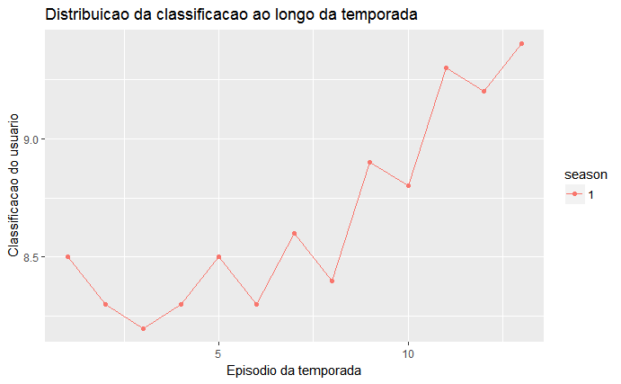

```r
dados %>%  filter(series_name == "13 Reasons Why") %>%
  mutate(season = as.character(season)) %>%
  ggplot(aes(x = season_ep, y = UserRating, color = season)) +
  geom_line() +
  geom_point() +
  labs(title = "Distribuicao da classificacao ao longo da temporada", x="Episodio da temporada", y="Classificacao do usuario")
```

```r
dados %>%  filter(series_name == "13 Reasons Why") %>%
    group_by(season) %>%
    summarise(correlacao_linear = cor(season_ep, UserRating,
                                      method = "pearson"),
              correlacao_kendall = cor(season_ep, UserRating,
                                       method = "kendall"))
```

| season | correlacao_linear | correlacao_kendall |
| --- | --- | --- |
| 1 | 0.8650644 | 0.6844476 |

**Descricao da variavel votos dos usuarios (UserVotes)**

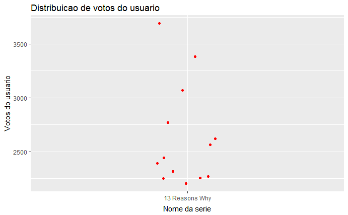

```r
dados %>%
  filter(series_name == "13 Reasons Why") %>%
    ggplot(aes(x = series_name, y = UserVotes)) +
    geom_jitter(width = .1, color = "red") +
labs(title = "Distribuicao de votos do usuario", x="Nome da serie", y="Votos do usuario")
```

```r
median((dados %>%  filter(series_name == "13 Reasons Why"))$UserVotes)
```

```
[1] 2445
```

```r
mean((dados %>%  filter(series_name == "13 Reasons Why"))$UserVotes)
```

```
[1] 2632.923
```

Podemos tambem observar a distribuicao dos votos por temporada de 13 Reasons Why. A primeira temporada, unica presente nos dados, tem numero de votos em termos de mediana de 2445 como vemos no grafico abaixo.

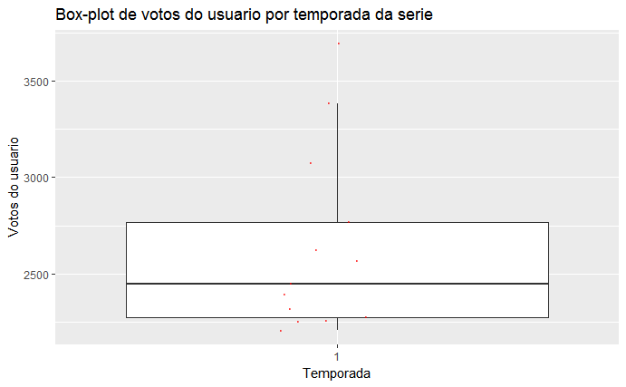

```r
dados %>%  filter(series_name == "13 Reasons Why") %>%
    ggplot(aes(x = as.character(season), y = UserVotes)) +
    geom_boxplot(outlier.color = NA) +
    geom_jitter(width = .1, size = .5, alpha = .5, color = "red")+
  labs(title = "Box-plot de votos do usuario por temporada da serie", x="Temporada", y="Votos do usuario")
```

Com o passar dos episodios de 13 Reasons Why da primeira temporada o episodio com menor numero de votos foi registrado no episodio 8. Felizmente, logo apos o episodio 12 e registrado o maior numero de votos da serie como podemos ver no grafico abaixo.

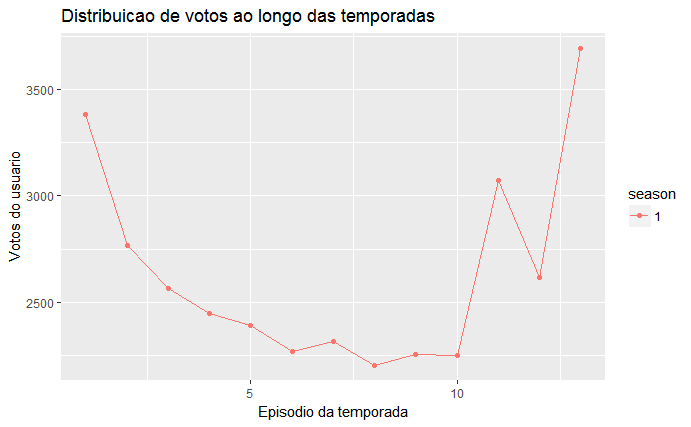

```r
dados %>%  filter(series_name == "13 Reasons Why") %>%
  mutate(season = as.character(season)) %>%
  ggplot(aes(x = season_ep, y = UserVotes, color = season)) +
  geom_line() +
  geom_point() +
  labs(title = "Distribuicao de votos ao longo das temporadas", x="Episodio da temporada", y="Votos do usuario")
```

Quanto a correlacao entre o episodio da temporada e seu numero de votos podemos perceber a desistencia de uma correlacao linear forte.

```r
dados %>%  filter(series_name == "13 Reasons Why") %>%
    group_by(season) %>%
    summarise(correlacao_linear = cor(season_ep, UserVotes,
                                      method = "pearson"),
              correlacao_kendall = cor(season_ep, UserVotes,
                                       method = "kendall"))
```

| season | correlacao_linear | correlacao_kendall |
| --- | --- | --- |
| 1 | 0.09939289 | -0.1794872 |

# `Pergunta 1`

**Qual das series que voce escolheu no checkpoint 1 e mais votada pelos usuarios do IMDB? E a menos votada? A diferenca e grande? Pequena?** *Possível resposta: Acredito que a mais votada seja Sense8 e a menos votada seja Black Mirror com diferenca grande.*

Aparentemente a serie mais bem votada e a serie Black Mirror se observar-mos o grafico de dispersao abaixo e levarmos em consideracao os votos do usuario (UserVotes) e a mediana como metrica de comparacao.

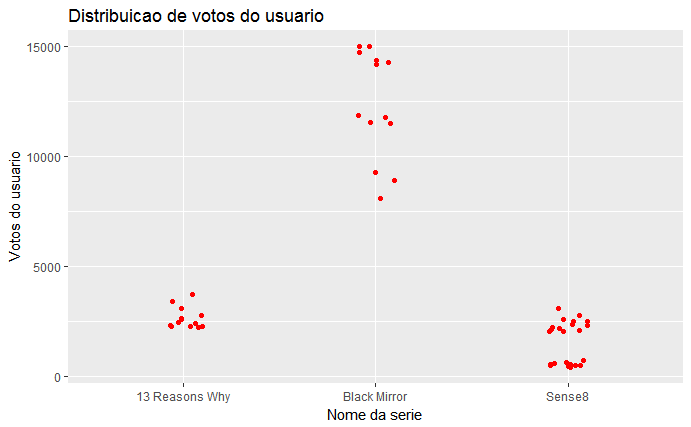

```r
dados %>%
    ggplot(aes(x = series_name, y = UserVotes)) +
    geom_jitter(width = .1, color = "red")  +
  labs(title = "Distribuicao de votos do usuario", x="Nome da serie", y="Votos do usuario")
```

Para observar melhor qual delas e mais bem votada segundo os votos do usuario vamos olhar para o grafico de box plot de cada uma das series.

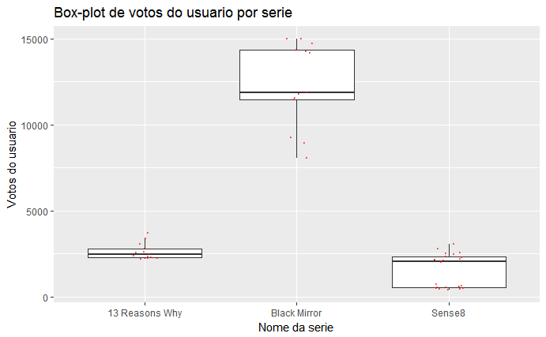

```r
dados %>%
    ggplot(aes(x = series_name, y = UserVotes)) +
    geom_boxplot(outlier.color = NA) +
    geom_jitter(width = .1, size = .5, alpha = .5, color = "red")+
  labs(title = "Box-plot de votos do usuario por serie", x="Nome da serie", y="Votos do usuario")
```

Olhando para o grafico acima e utilizando a mediana como metrica de comparacao entre as series, fica claro que Black Mirror e a serie mais bem votada e a menos votada fica sendo Sense 8(por uma diferenca muito pequena com relacao a 13 Reasons Why). A mediana e uma boa metrica porque ajuda a perceber onde fica a maior concentracao de votos do usuario diminuindo o vies de outliers. Neste caso em particular, independente de ser utilizado a metrica mediana ou media os resultados iriam ser os mesmos.

Ainda sobre a diferenca de cada uma das series vemos que a mediana de votos das series 13 Reasons Why e Sense8 esta entre 0 e 2500, podendo se considerar que, e pequena a diferenca de votos entre elas e grande entre Black Mirror e 13 Reasons Why e Black Mirror e Sense8 como vemos no grafico acima.

Conclusao: O senso comum leva a crer que pelo fato de Sense8 ser a serie mais bem classificada pelos usuarios segundo o IMDB (Checkpoint 1) entao, certamente, ela seria a serie mais votada pelos usuarios(altos votos levam a alta classificacao). Isto significa que a a classificacao dos usuarios segundo o IMDB leva em consideracao algo alem do numero de votos que os usuarios dao a um episodio ja que a serie mais bem votada foi Black Mirror e nao Sense8.

Nova pergunta: Com o intuito de certificar se existe ou não uma relação entre a classificacao dos usuarios segundo o IMDB (UserRating) e o numero de votos dos usuarios (UserVotes), qual o coeficiente de corelacao linear entre essas duas variaveis?

```r
dados %>% group_by(series_name) %>%
    summarise(correlacao_linear = cor(UserVotes, UserRating,
                                      method = "pearson"),
              correlacao_kendall = cor(UserVotes, UserRating,
                                       method = "kendall"))
```

| series_name | correlacao_linear | correlacao_kendall |
| --- | --- | --- |
| 13 Reasons Why | 0.4856838 | 0.1579494 |
| Black Mirror | 0.4829252 | 0.2252891 |
| Sense8 | -0.6893093 | -0.4981227 |

# `Pergunta 2`

**Qual o episodio, das series que voce escolheu no checkpoint 1, que foi mais bem avaliado segundo o IMDB? E o que foi menos avaliado? A diferenca e grande? Pequena?** *Possivel resposta: Acredito que os mais bem avaliado seja o primeiro episodio em cada uma das series e que o menos avaliado seja os episodios do meio ou decorrer.*

O episodio de Sense8 mais bem avaliados foi o episodios 11 da segunda temporada e o menos avaliado foi o episodio 1 da primeira temporada como podemos ver no grafico abaixo. Quanto a diferenca pode-se dizer que e grande, o episodio 11 teve avaliacao superior a 9.5 enquanto o episodio 1 teve 7.5(diferenca de pelo menos 2 pontos).

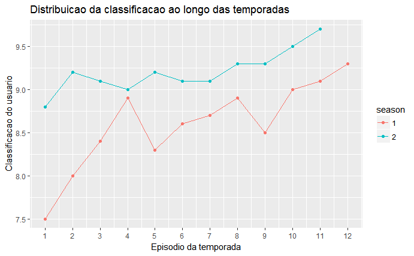

```r
dados %>%  filter(series_name == "Sense8") %>%
  mutate(season = as.character(season)) %>%
  ggplot(aes(x = season_ep, y = UserRating, color = season)) +
  geom_line() +
  geom_point()+
  scale_x_continuous(breaks=seq(1, 12, 1)) +
  labs(title = "Distribuicao da classificacao ao longo das temporadas", x="Episodio da temporada", y="Classificacao do usuario")
```

O episodio de Black Mirror mais bem avaliado foi o episodios 4 da segunda temporada e o menos avaliado foi o episodio 3 da mesma temporada como podemos ver no grafico abaixo. Quanto a diferenca pode-se dizer que e grande, o episodio 4 teve avaliacao superior a 9.0 enquanto o episodio 3 teve avaliacao 7.0(diferenca de pelo menos 2 pontos).

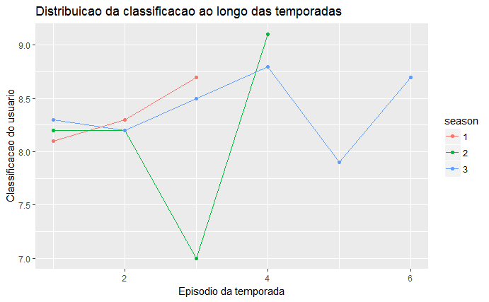

```r
dados %>%  filter(series_name == "Black Mirror") %>%
  mutate(season = as.character(season)) %>%
  ggplot(aes(x = season_ep, y = UserRating, color = season)) +
  geom_line() +
  geom_point() +
labs(title = "Distribuicao da classificacao ao longo das temporadas", x="Episodio da temporada", y="Classificacao do usuario")
```

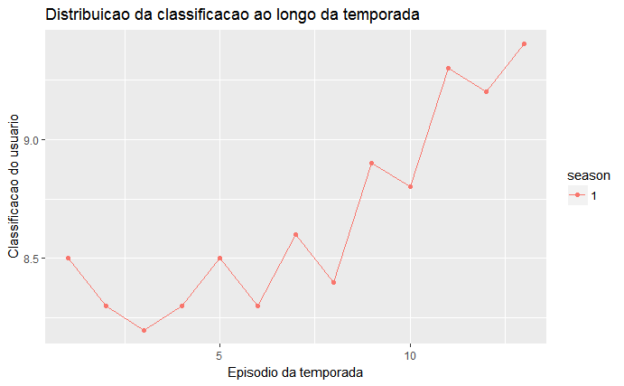

```r
dados %>%  filter(series_name == "13 Reasons Why") %>%
  mutate(season = as.character(season)) %>%
  ggplot(aes(x = season_ep, y = UserRating, color = season)) +
  geom_line() +
  geom_point() +
  labs(title = "Distribuicao da classificacao ao longo da temporada", x="Episodio da temporada", y="Classificacao do usuario")
```

Conclusao: Como podemos ver o primeiro episodio de cada uma das series nao e o mais bem avaliado e apenas as series 13 Reasons Why e Black Mirror tiveram o episodio menos bem avaliado no decorrer da temporada.

Nova pergunta: Para as series que possuem mais de uma temporada, a avaliacao dos episodios de uma nova temporada cresceu ou decresceu quando comparados a avaliacao dos episodios da temporada anterior?

As unicas series dentre as 3 escolhidas possuidoras de mais de uma temporada sao Sense8 e Black Mirror.

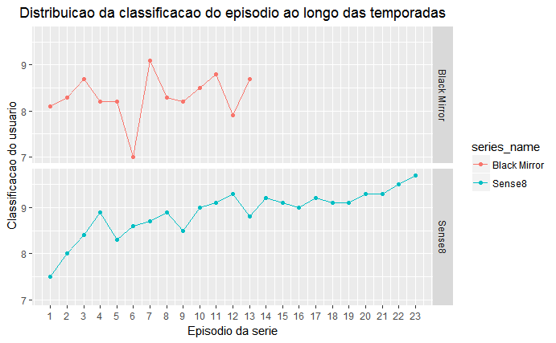

```r
dados %>%
  filter(series_name != "13 Reasons Why") %>%
  ggplot(aes(x = series_ep, y = UserRating, color = series_name)) +
  geom_line() +
  geom_point() +
  scale_y_continuous() +
  scale_x_continuous(breaks=seq(1,23,1)) +
  facet_grid(series_name ~ .) +
  xlab("Episodio da serie") +
  ylab("Classificacao do usuario") +
  ggtitle("Distribuicao da classificacao do episodio ao longo das temporadas") +
  theme(plot.title = element_text(hjust = 0.5))
```

Olhando para o grafico acima fica facil observar se a avaliacao dos episodios da nova temporada cresce ou decresce quando comparados a temporada anterior. Black Mirror apresenta uma variacao da avaliacao dos episodios com o passar das temporadas mas fica dificil afirmar com precisao se a avaliacao dos episodios cresceu ou decresceu.

Observando Sense8 podemos observar um crescimento da avaliacao dos episodios.

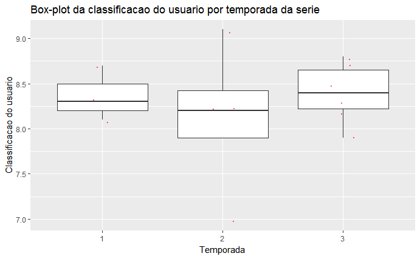

```r
dados %>%  filter(series_name == "Black Mirror") %>%
    ggplot(aes(x = as.character(season), y = UserRating)) +
    geom_boxplot(outlier.color = NA) +
    geom_jitter(width = .1, size = .5, alpha = .5, color = "red")+
  labs(title = "Box-plot da classificacao do usuario por temporada da serie", x="Temporada", y="Classificacao do usuario")
```

Observando o grafico acima fica facil perceber como se comporta a avaliacao dos episodios com o passar das temporadas de Black Mirror. Percebe-se claramente que a serie mantem a avaliacao dos episodios se utilizamos a mediana para comparar cada temporada. Ou seja, a serie manteve a avaliacao dos episodios.

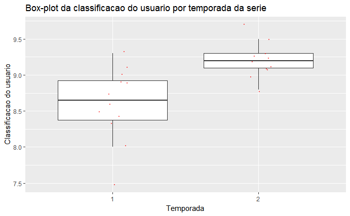

```r
dados %>%  filter(series_name == "Sense8") %>%
    ggplot(aes(x = as.character(season), y = UserRating)) +
    geom_boxplot(outlier.color = NA) +
    geom_jitter(width = .1, size = .5, alpha = .5, color = "red")+
  labs(title = "Box-plot da classificacao do usuario por temporada da serie", x="Temporada", y="Classificacao do usuario")
```

Observando o grafico acima fica facil perceber como se comporta a avaliacao dos episodios com o passar das temporadas de Sense8. Percebe-se claramente o crescimento da avaliacao dos episodios se utilizamos a mediana para comparar cada temporada. Ou seja, houve um crescimento da avaliacao dos episodios.

Respondendo a pergunta: a avaliacao dos episodios das novas temporadas de Black Mirror foi mantida variando sob uma razao de decimos, ja a avaliacao dos episodios da nova temporada de Sense8 houve um crescimento quando comparados a avaliacao dos episodios da temporada anterior.

Copyright © 2017 [Marcos Nascimento](http://https://github.com/marcosasn/AD1/tree/master/problema1/R)